# NHANES 2017-2020: Health Insurance and Blood-Sugar Screening

Inverse Probability Weighting (IPW)

Amanda Millatt

June 11, 2026

```r
#Loading and bringing in the required packages

pkgs <- c("cobalt", "survey", "dplyr", "ggplot2", "boot")

to_install <- pkgs[!pkgs %in% rownames(installed.packages())]
if (length(to_install)) install.packages(to_install)
invisible(lapply(pkgs, library, character.only = TRUE))
```

```
##  cobalt (Version 4.6.3, Build Date: 2026-05-29)
```

```r
#Pulling in the final dataset

df <- read.csv("nhanes_insurance_screening_analytic.csv")

theme_set(theme_minimal(base_size = 12))
```

# 1.Estimating propensity score through a logistic regression model

The propensity score, which is the probability of treatment, is calculated by first regressing the *insurance status* on the covariates identified from DAG (included the covariates below for reference). All covariates identified were confounders in the causal pathway from *insurance status* to *blood sugar screening*.

- *Demographic / socioeconomic:* age, sex, race/ethnicity, education, family income-to-poverty ratio, marital status, country of birth, interview language.
- *Health status / risk:* BMI, self-rated general health, prior hypertension diagnosis.
- *Health behavior:* ever-drinking alcohol, ever-smoking.

```r
ps_model <- glm(
  I(insured == "Insured") ~ age + sex + race_eth + education +
                           pir + marital + us_born + interview_lang +
                           bmi + gen_health + hypertension + smoked_100 + alcohol_ever,
  data = df,
  family = binomial(link = "logit"),
  na.action = na.exclude
)
df$propensity_score <- predict(ps_model, type = "response")

summary(df$propensity_score)
```

```
##    Min. 1st Qu.  Median    Mean 3rd Qu.    Max.     NAs
##  0.1883  0.7546  0.8840  0.8336  0.9508  0.9955    1954
```

# 2. Checking propensity score overlap by levels of Insurance Status

To verify that the propensity score found enough matches between the insured and uninsured group, a density plot of the propensity scores were created to visualize the overlapping areas.

*Analysis of the curve:* The plot below shows a huge spike close to 1 for the insured group indicating that a large group of units are “near-certain” to be insured (propensity Score > 0.9). These individuals are extremely likely to have health insurance regardless of their baseline characteristics.While, the uninsured group showed a decline in propensity score density near 0.95 -1.This means there are very few uninsured units who are similar to the units in that insured spike. Due to the extreme propensity scores, the estimated ATE will be highly dependent on the regression model’s extrapolation causing a slightly biased ATE estimate.

*Conclusion*: Covariate balance will be evaluated after applying stabilized IPW weights using a love plot, which will indicate if further methods such as as Overlap Weighting (OW) or Covariate Balancing Propensity Score (CBPS).

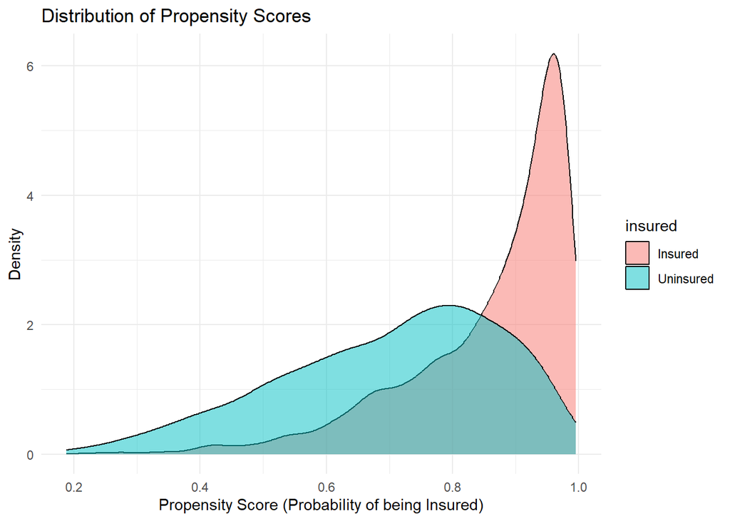

```r
ggplot(df, aes(x = propensity_score, fill = insured)) +
  geom_density(alpha = 0.5) +
  labs(title = "Distribution of Propensity Scores",
       x = "Propensity Score (Probability of being Insured)",
       y = "Density") +
  theme_minimal()
```

# 3. Calculating Stabilized IPW Weights

To estimate ATE while adjusting for covariates, stabilized inverse probability weights were employed. Unstabilized IPW weights can often be highly variable, especially when propensity scores are extreme, which may lead to biased estimates with large variance. Stabilized weights mitigate this by introducing the marginal probability of treatment ($P(T=1)$) into the numerator. In turn, the stabilized weights will reduce variance and ensure the weighted sample size is consistent with the orginal sample.

```r
df$ps <- predict(ps_model, type = "response")

df <- df%>%
  mutate(
    ipw = ifelse(insured == "Insured",
                 mean(insured == "Insured") / ps,
                 (1 - mean(insured == "Insured")) / (1 - ps))
  )

ipw_summary <- df%>%
  group_by(insured) %>%
  summarise(
    "N (Sample Size)" = n(),
    "Mean Stabilized Weight" = mean(ipw, na.rm = TRUE),
    "Min Weight" = min(ipw, na.rm = TRUE),
    "Max Weight" = max(ipw, na.rm = TRUE)
  )

ipw_summary
```

| insured | N (Sample Size) | Mean Stabilized Weight | Min Weight | Max Weight |
| --- | --- | --- | --- | --- |
| Insured | 6166 | 0.9918774 | 0.8296362 | 4.003815 |
| Uninsured | 1300 | 1.0046391 | 0.2145032 | 12.228852 |

# 4. Intergrating sampling weights from NHANES and fitting the Outcome Model using a logistic regression with a binomial distribution

To run the regression model, the NHANES data had to be filtered for complete rows and then the final weights were calculated by integrating the sampling design weights with the calculated stabilized IPW weights. The *Screened* and *Insured* variables were converted into a 0/1 numeric format compatible with logistic regression. Next, the svydesign function constructs a complex survey design object using NHANES specific stratification and cluster variables to ensure statistically valid inferences. Finally, the binomial logistic regression model was fitted to estimate the effect of insurance status on diabetes screening. The dispersion parameter was checked to ensure there was no over dispersion from the binomial distribution. The dispersion parameter was 1.000181, which indicates that the use of the binomial distribution was appropriate.

```r
df_clean <- df[!is.na(df$ipw), ]

df_clean $final_weight <- df_clean $WTMECPRP * df_clean$ipw

#Changing the variables from string to numeric to run the regression model
df_clean$screened_recoded <- ifelse(df_clean$screened == "Screened", 1, 0)

df_clean$insured_recoded <- ifelse(df_clean$insured == "Insured", 1, 0)

nhanes_ipw_design <- svydesign(
  id      = ~SDMVPSU,
  strata  = ~SDMVSTRA,
  weights = ~final_weight,
  data    = df_clean ,
  nest    = TRUE
)


#fitting the regression model with modified weights to account for the complexity of the sampling design weights calculated by NHANES
m_ipw <- svyglm(
  screened_recoded ~ insured_recoded,
  design = nhanes_ipw_design,
  family = binomial(link = "logit")
)
summary(m_ipw)
```

```
##
## Call:
## svyglm(formula = screened_recoded ~ insured_recoded, design = nhanes_ipw_design,
##     family = binomial(link = "logit"))
##
## Survey design:
## svydesign(id = ~SDMVPSU, strata = ~SDMVSTRA, weights = ~final_weight,
##     data = df_clean, nest = TRUE)
##
## Coefficients:
##                 Estimate Std. Error t value Pr(>|t|)
## (Intercept)      -0.5368     0.1336  -4.017 0.000505 ***
## insured_recoded   0.7770     0.1350   5.754 6.26e-06 ***
## ---
## Signif. codes:  0 '***' 0.001 '**' 0.01 '*' 0.05 '.' 0.1 ' ' 1
##
## (Dispersion parameter for binomial family taken to be 1.000181)
##
## Number of Fisher Scoring iterations: 4
```

```r
#Check for over dispersion
m_summary <- summary(m_ipw)
dispersion_param <- m_summary$dispersion

cat("The estimated dispersion parameter is:", dispersion_param, "\n")
```

```
## The estimated dispersion parameter is: 1.000181
```

# 5. Create the love plot to examine covariate balance before and after adjustment

A love plot was created to examine the covariate blanace by levels of insurance coverage with the ideal absolute standardized mean differences (SMD) threshold set at 0.1. The love plot demonstrates the effectiveness of inverse probability weighting in balancing the covariate with the absolute SMD for most variables reduced to below the 0.1 threshold after adjustment. This indicates improved comparability between the insured and uninsured groups.

Please note: Although the SMD improved for all variables, *pir*, *education_College graduate*,*education_< High school* and *race_eth_Non-Hispanic White* were all above the 0.1 threshold.

```
## Note: `s.d.denom` not specified; assuming "pooled".
```

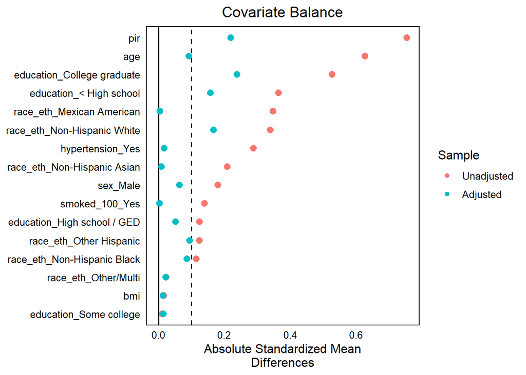

```r
love.plot(
  insured_recoded ~ age + sex + race_eth + education + pir + bmi + hypertension + smoked_100,
  data = df_clean,
  weights = df_clean$final_weight,
  binary = "std",
  threshold = 0.1,
  abs = TRUE,
  var.order = "unadjusted"
)
```

# 6. Calculate the ATE

The Average Treatment Effect (ATE) was calculated by predicting the probability of diabetes screening for every unit under both insured and uninsured scenarios (potential outcomes) based on the previously fitted binomial logistic regression model.Then, the absolute difference of screening probability for each unit in the sample was estimated by subtracting these units predictions. The original NHANES survey weights **WTMECPRP** to these differences to ensure the estimate was nationally representative of the U.S. population. Finally, the weighted ATE was computed.

```r
pred_ins   <- predict(m_ipw, newdata = mutate(df_clean, insured_recoded = 1),   type = "response")
pred_unins <- predict(m_ipw, newdata = mutate(df_clean, insured_recoded = 0), type = "response")

# Weighted ATE
ate_diff <- (pred_ins - pred_unins) * df_clean$WTMECPRP
ate_ipw  <- sum(ate_diff, na.rm = TRUE) / sum(df_clean$WTMECPRP, na.rm = TRUE)

cat("IPW-Adjusted ATE:", round(ate_ipw, 4), "\n")
```

```
## IPW-Adjusted ATE: 0.1908
```

# 7. Calculating the 95% confidence interval from bootstrapping with replacement

```r
#Creating a loop function to calculate IPW for each iteration
boot_ate_fn <- function(data, indices) {
  d_boot <- data[indices, ]

  d_boot$insured_recoded  <- ifelse(d_boot$insured == "Insured", 1, 0)
  d_boot$screened_recoded <- ifelse(d_boot$screened == "Screened", 1, 0)

#estimate propensity score model

  ps_m_boot <- glm(
    insured_recoded ~ age + sex + race_eth + education +
                      pir + marital + us_born + interview_lang +
                      bmi + gen_health + hypertension + smoked_100 + alcohol_ever,
    data = d_boot,
    family = binomial(link = "logit"),
    na.action = na.exclude
  )
  d_boot$ps <- predict(ps_m_boot, type = "response")

#calculate stabilized IPW weights
  p_insured_boot <- mean(d_boot$insured_recoded == 1, na.rm = TRUE)
  d_boot <- d_boot %>%
    mutate(
      ipw = ifelse(insured_recoded == 1,
                   p_insured_boot / ps,
                   (1 - p_insured_boot) / (1 - ps))
    )

#Filter for out the blank values and merge with NHANES sampling design weights
  d_boot_clean <- d_boot[!is.na(d_boot$ipw), ]
  d_boot_clean$final_weight <- d_boot_clean$WTMECPRP * d_boot_clean$ipw

#Scale the weights to protect standard glm
  d_boot_clean$final_weight_scaled <- d_boot_clean$final_weight / mean(d_boot_clean$final_weight, na.rm = TRUE)

#Fit outcome model using scaled weights
  m_boot <- glm(
    screened_recoded ~ insured_recoded,
    data = d_boot_clean,
    weights = final_weight_scaled,
    family = binomial(link = "logit")
  )

#Predict potential outcomes and compute ATE
  p_ins   <- predict(m_boot, newdata = mutate(d_boot_clean, insured_recoded = 1), type = "response")
  p_unins <- predict(m_boot, newdata = mutate(d_boot_clean, insured_recoded = 0), type = "response")

  boot_ate_diff <- (p_ins - p_unins) * d_boot_clean$WTMECPRP
  boot_ate_ipw  <- sum(boot_ate_diff, na.rm = TRUE) / sum(d_boot_clean$WTMECPRP, na.rm = TRUE)

  return(boot_ate_ipw)
}

#Run the bootstrap (500 iterations)
set.seed(123)
boot_results <- boot(data = df, statistic = boot_ate_fn, R = 500)
```

[output not shown]

[output cut: 446 more lines]

[output not shown]

```r
#Extract the 95% Confidence Interval from the bootstrapped sample
boot_ci <- boot.ci(boot_results, type = "perc")
cat("Bootstrapped 95% Confidence Interval [", round(boot_ci$percent[4], 4), ",", round(boot_ci$percent[5], 4), "]\n")
```

```
## Bootstrapped 95% Confidence Interval [ 0.1083 , 0.2688 ]
```